# Disciplina - DQF10648 Eletromagnetismo I

## Aula em 15/07/2021 - Semestre 2021/1 EARTE

### [DQF - CCENS](http://alegre.ufes.br/ccens/departamento-de-quimica-e-fisica) - [UFES/Alegre](http://alegre.ufes.br/)

### Professor : [Roberto Colistete Jr.](https://github.com/rcolistete)

### (TAREFA PASSADA) Cálculo integral e seus teoremas em análise vetorial

### Tarefa passada na aula anterior

Procurar demonstrações no ["Wolfram Demonstrations Project"](https://demonstrations.wolfram.com/) sobre os teoremas e/ou integrais da aula anterior sobre "Cálculo integral e seus teoremas em análise vetorial", para mostrar na aula.

Alguém ?

R.: ninguém fez ou mostrou.

# Eletrostática

## Campo Elétrico $\vec{E}$ gerado por distribuição contínua de cargas elétricas

Motivações :

- compreender como montar a integral para campo elétrico a partir de qualquer distribuição contínua de cargas elétricas, quer seja em volume, em superfície ou linha;
- sempre fazer diagrama gráfico da região com cargas elétricas para facilitar a compreensão e modelagem do problema;
- praticar coordenadas cilíndricas e integral curvilínea, no caso do anel circular.

### Campo Elétrico $\vec{E}$ gerado por distribuição volumétrica de cargas elétricas

Se a densidade volumétrica de carga elétrica $\rho$ $(\propto C/m^3)$ for dada em uma região, então sempre é possível calcular o campo elétrico $\vec{E}(\vec{r}_0)$ na posição $\vec{r}_0$ da carga-teste $q_0$ :

$$ \vec{E} = \int\int\int_R d\vec{E}\,dV' \,\,\, \rightarrow \,\,\, \vec{E}(\vec{r}_0) = \int\int\int_R d\vec{E}(\vec{r}_0, \vec{r}')\,dV'$$

onde o diferencial de campo elétrico $d\vec{E}$ produzido por um diferencial de carga elétrica $dq'$ é dado genericamente como :

$$ d\vec{E} = \frac{dq'\,\hat{r}}{4\pi\epsilon_0\,|\vec{r}|^2} = \frac{dq'\,\hat{r}}{4\pi\epsilon_0\,r^2} = \frac{dq'\,\vec{r}}{4\pi\epsilon_0\,|\vec{r}|^3} = \frac{dq'\,\vec{r}}{4\pi\epsilon_0\,r^3} \,\,\,, \,\,\, \textrm{pois} \,\,\, \hat{r} = \frac{\vec{r}}{|\vec{r}|} e \,\,\, r = |\vec{r}| $$

Em um volume espacial, $dq' = \rho(\vec{r}')\,dV'$ :

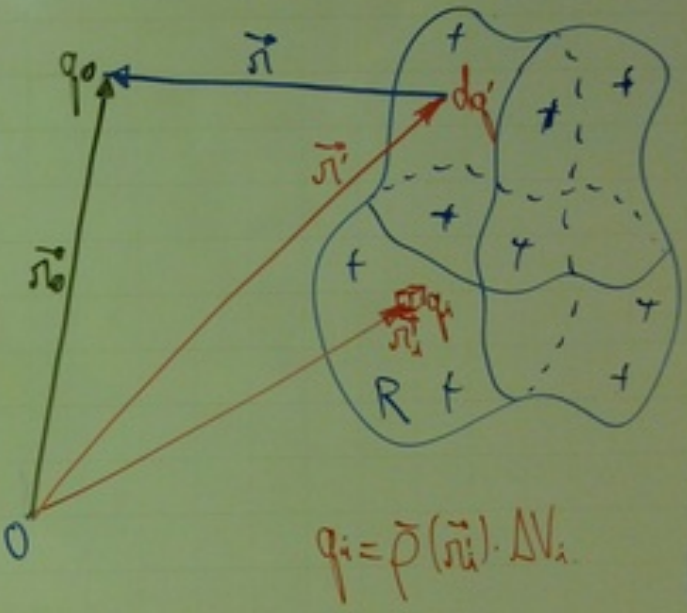

$$ \vec{E}(\vec{r}_0) = \frac{1}{4\pi\epsilon_0}\int\int\int_R \frac{\rho(\vec{r}')\,\vec{r}\,dV'}{|\vec{r}|^3} = \frac{1}{4\pi\epsilon_0}\int\int\int_R \frac{\rho(\vec{r}')(\vec{r}_0-\vec{r}')\,dV'}{|\vec{r}_0-\vec{r}'|^3} $$

onde :

- $R$ é uma região tridimensional que contém a distribuição contínua de cargas elétricas;
- $dV'$ é o diferencial de volume da região $R$;
- $\rho(\vec{r}')$ é a densidade volumétrica de carga elétrica, $(\propto C/m^3)$, na região $R$;
- $\vec{r}$ é o vetor que sai da posição de $dq'$ até a posição da carga-teste $q_0$, i.e., $\vec{r} = \vec{r}_0-\vec{r}'$;
- $\vec{r}_0$ é o vetor-posição da carga-teste $q_0$ e do observador da medida;
- $\vec{r}'$ é o vetor-posição que varre todas as cargas na região $R$.

### Campo Elétrico $\vec{E}$ gerado por distribuição superficial de cargas elétricas

Se a densidade superficial de carga elétrica $\sigma$ $(\propto C/m^2)$ for dada em uma superfície $S$ :

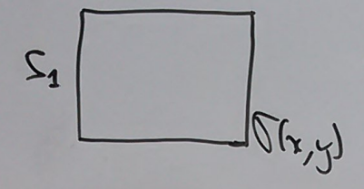

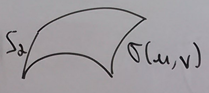

então sempre é possível calcular o campo elétrico produzido via :

$$ \vec{E}(\vec{r}_0) = \frac{1}{4\pi\epsilon_0}\int\int_S \frac{\sigma(\vec{r}')\,\vec{r}\,dA'}{|\vec{r}|^3} = \frac{1}{4\pi\epsilon_0}\int\int_S \frac{\sigma(\vec{r}')(\vec{r}_0-\vec{r}')\,dA'}{|\vec{r}_0-\vec{r}'|^3} $$

onde :

- $S$ é uma superfície que contém a distribuição contínua de cargas elétricas;
- $dA'$ é o diferencial de área da superfície $S$;
- $\sigma(\vec{r}')$ é a densidade superficial de carga elétrica, $(\propto C/m^2)$, na superfície $S$.

### Campo Elétrico $\vec{E}$ gerado por distribuição linear de cargas elétricas

Se a densidade linear de carga elétrica $\lambda$ $(\propto C/m)$ for dada em uma curva $C$ :

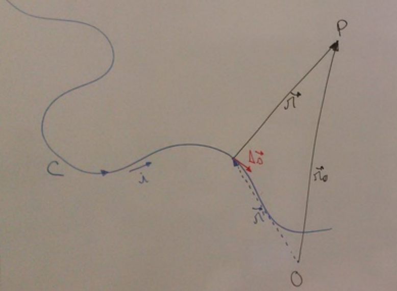

então sempre é possível calcular o campo elétrico produzido via :

$$ \vec{E}(\vec{r}_0) = \frac{1}{4\pi\epsilon_0}\int_C \frac{\lambda(\vec{r}')\,\vec{r}\,ds'}{|\vec{r}|^3} = \frac{1}{4\pi\epsilon_0}\int_C \frac{\lambda(\vec{r}')(\vec{r}_0-\vec{r}')\,ds'}{|\vec{r}_0-\vec{r}'|^3} $$

onde :

- $C$ é uma curva que contém a distribuição contínua de cargas elétricas;
- $ds'$ é o diferencial de comprimento da curva $C$;
- $\lambda(\vec{r}')$ é a densidade linear de carga elétrica, $(\propto C/m)$, na curva $C$.

## Exemplo 1 : Anel circular carregado eletricamente

a) Calcule o campo elétrico $\vec{E}$ criado por um anel circular carregado eletricamente;

b) idem (a), porém restringindo o observador ao longo do eixo do anel (eixo ortogonal ao plano do anel circular);

c) idem (a), porém restringindo para distribuição homogênea de cargas elétricas no anel;

d) idem (b), porém restringindo para distribuição homogênea de cargas elétricas no anel. Caso mais usado por ser mais simples.

### Solução de (1.a)

Passo-a-passo genérico para cálculo de $\vec{E}$ produzido por distribuição contínua de cargas elétricas :

1. **faça um diagrama gráfico** com a origem do sistema de coordenadas, a carga-teste $q_0$ (observador da medida) e o vetor-posição $\vec{r}_0$, a região com distribuição contínua de cargas elétricas com ao menos um ponto tendo um $dq'$ e vetor-posição $\vec{r}'$, e o vetor-posiçao $\vec{r} = \vec{r}_0 - \vec{r}'$ que sai de $dq'$ em direção a $q_0$;
1. como a região com distribuição contínua de cargas elétricas será varrida via integral, então tente posicionar no sistema de coordenadas tal região com distribuição contínua de cargas elétricas tal que a modelagem/representação da região seja simplificada;
1. dado o tipo da região que contém a distribuição contínua de cargas elétricas, **escolha a expressão de $\vec{E}$ adequada**;
1. **escolha o sistema de coordenadas curvilíneas mais adequado** à distribuição contínua de cargas elétricas, em termos de simetria da região e como varia a densidade de cargas elétricas na mesma.

Passo (1)-(2) $-$ Vamos aproveitar a simetria do anel circular e colocá-lo no plano $xy$, centrado na origem $O$ :

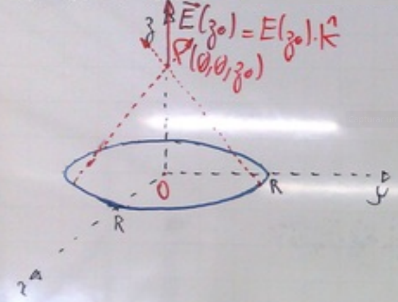

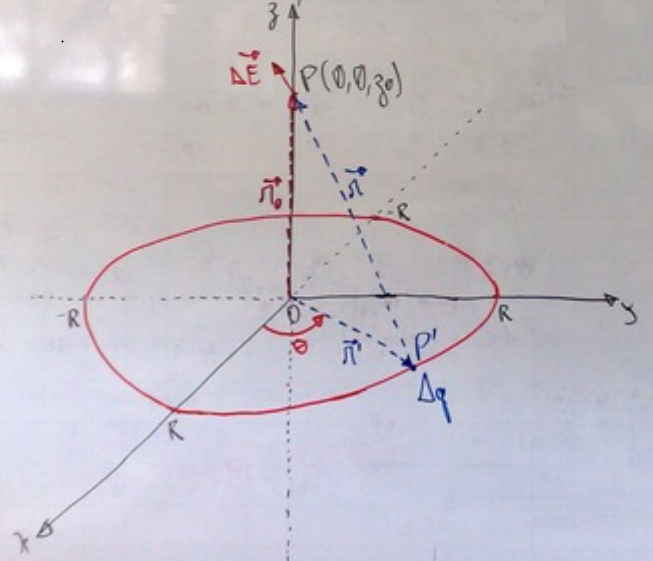

Passo (3) $-$ Para calcular o campo elétrico $\vec{E}$ criado por um anel circular de raio $R$ carregado eletricamente, usaremos a expressão com densidade linear de carga elétrica $\lambda$ $(\propto C/m)$ dada em uma curva $C$ :

$$ \vec{E}(\vec{r}_0) = \frac{1}{4\pi\epsilon_0}\int_C \frac{\lambda(\vec{r}')(\vec{r}_0-\vec{r}')\,ds'}{|\vec{r}_0-\vec{r}'|^3} $$

sendo que $\lambda(\vec{r}')$ é a densidade linear de carga elétrica, $(\propto C/m)$, na curva $C$, sendo uma função genérica de $\vec{r}'$.

Passo (4) $-$ Dado que :

- a curva $C$ é uma circunferência de raio $R$, e escolhemos como centrada na origem do plano $xy$;
- $ds'$ é o diferencial de comprimento (de arco) de uma circunferência de raio $R$, i.e., $ds' = R\,d\theta'$;
- $\lambda(\vec{r}')$ só depende de $\theta'$ ao longo da circunferência, i. e., $\lambda(\vec{r}') = \lambda(\theta')$.
- $\vec{r}'$ é o vetor-posição que sai da origem $O$ até cada ponto da circunferência (com diferencial de carga elétrica $dq'$);

então o mais adequado é adotar coordenadas curvilíneas que se comportem no plano $xy$ como coordenadas polares $(\rho, \theta)$, por exemplo, coordenadas cilíndricas $(\rho, \theta, z)$ ou coordenadas esféricas $(r, \theta, \phi)$.

Vamos adotar coordenadas cilíndricas por serem mais simples.

Assim, em coordenadas cilíndricas, ao longo da circunferência de raio $R$ centrada na origem :

$$\textrm{curva}\,C : \begin{cases} \rho' = R \\\\ \theta' \in [0, 2\,\pi]\,\textrm{rad} \\\\ z' = 0\,\textrm{m} \end{cases}$$

$$ds' = R\,d\theta'$$

$$\lambda(\vec{r}') = \lambda(\theta')$$

$$\vec{r}' = \rho'\,\hat{\rho} = R\,\hat{\rho} = R\cos\theta'\,\hat{i} + R\sin\theta'\,\hat{j} \,\,\, \rightarrow \,\,\, |\vec{r}'| = r' = R $$

$$\vec{r}_0 = \rho_0\,\hat{\rho} + z_0\,\hat{k} = \rho_0\cos\theta_0\,\hat{i} + \rho_0\sin\theta_0\,\hat{j} + z_0\,\hat{k} = x_0\,\hat{i} + y_0\,\hat{j} + z_0\,\hat{k} \,\,\, , \textrm{onde} \,\,\, |\vec{r}_0| = r_0 $$

Sobre vetor posição em coordenadas cilíndricas, vide [seção "5.3.9 Vetor Posição", pág. 78m da referência [Barcarena3]](https://aedmoodle.ufpa.br/pluginfile.php/354040/mod_resource/content/1/topico3.pdf).

Logo temos que $\vec{E}$ é uma integral em relação a $\theta'$ :

$$ \vec{E}(\vec{r}_0) = \frac{1}{4\pi\epsilon_0}\int_0^{2\,\pi} \frac{\lambda(\theta')(\vec{r}_0-\vec{r}')\,R\,d\theta'}{|\vec{r}_0-\vec{r}'|^3} $$

Se tentarmos substituir $\vec{r}_0$ e $\vec{r}'$ pelas expressões em coordenadas cilíndricas, notar que $\hat{\rho}$ de cada um é diferente pois tal vetor unitário não é constante por depender do ponto em que é calculado, logo não é possível somar/subtrair vetores e fatorar as componentes sob mesmo $\hat{\rho}$.

Por isso vamos converter $\vec{r}_0$ e $\vec{r}'$ para coordenadas cilíndricas e em seguida para coordenadas cartesianas (vide página anterior), substituindo :

$$ \vec{E}(\vec{r}_0) = \frac{R}{4\pi\epsilon_0}\int_0^{2\,\pi} \frac{\lambda(\theta')[(x_0 - R\cos\theta')\hat{i} + (y_0 - R\sin\theta')\,\hat{j} + z_0\,\hat{k}]\,d\theta'}{|(x_0 - R\cos\theta')\hat{i} + (y_0 - R\sin\theta')\,\hat{j} + z_0\,\hat{k}|^3} $$

Se quisermos expandir ainda mais :

$$ \vec{E}(\vec{r}_0) = \frac{R}{4\pi\epsilon_0}\int_0^{2\,\pi} \frac{\lambda(\theta')[(x_0 - R\cos\theta')\hat{i} + (y_0 - R\sin\theta')\,\hat{j} + z_0\,\hat{k}]\,d\theta'}{[x_0^2 - 2 x_0 R \cos\theta' + R^2\cos^2\theta' + y_0^2 - 2 y_0 R\sin\theta' + R^2\sin^2\theta' + z_0^2]^{3/2}} $$

$$ \rightarrow \,\,\, \vec{E}(\vec{r}_0) = \frac{R}{4\pi\epsilon_0}\int_0^{2\,\pi} \frac{\lambda(\theta')[(x_0 - R\cos\theta')\hat{i} + (y_0 - R\sin\theta')\,\hat{j} + z_0\,\hat{k}]\,d\theta'}{[r_0^2 + R^2 - 2R(x_0\cos\theta' + y_0\sin\theta')]^{3/2}} $$

que é uma integral vetorial 3D (igual a 3 integrais simples) que descreve qualquer anel circular carregado eletricamente.

Tal integral pode ter solução analítica/simbólica em alguns casos de funções $\lambda(\theta')$ mais simples e vetor-posição $\vec{r}_0$ que explore a simetria do anel.

Mas na maioria dos casos a solução da integral é somente numérica/computacional.

Expandindo em 3 integrais simples escalares, uma para cada componente tridimensional de $\vec{E} = \vec{E}_x\hat{i} + \vec{E}_y\hat{j} + \vec{E}_z\hat{k}$ :

$$ E_x(\vec{r}_0) = \frac{R}{4\pi\epsilon_0}\int_0^{2\,\pi} \frac{\lambda(\theta')(x_0 - R\cos\theta') \,d\theta'}{[r_0^2 + R^2 - 2R(x_0\cos\theta' + y_0\sin\theta')]^{3/2}}$$

$$ E_y(\vec{r}_0) = \frac{R}{4\pi\epsilon_0}\int_0^{2\,\pi} \frac{\lambda(\theta')(y_0 - R\sin\theta')\,d\theta'}{[r_0^2 + R^2 - 2R(x_0\cos\theta' + y_0\sin\theta')]^{3/2}} $$

$$ E_z(\vec{r}_0) = \frac{R}{4\pi\epsilon_0}\int_0^{2\,\pi} \frac{\lambda(\theta')z_0\,\hat{k}\,d\theta'}{[r_0^2 + R^2 - 2R(x_0\cos\theta' + y_0\sin\theta')]^{3/2}}$$

A solução acima será abordada depois ao praticarmos gráficos de campos vetoriais 3D.

### Solução de (1.b)

Ao restringir o observador (posição da carga-teste) ao longo do eixo $z$ do anel (eixo ortogonal ao plano do anel circular), temos :

$$\vec{r}_0 = (0\,\textrm{m})\,\hat{\rho} + z_0\,\hat{k} = (0\,\textrm{m})\,\hat{i} + (0\,\textrm{m})\,\hat{j} + z_0\,\hat{k} = z_0\,\hat{k} \,\,\, , \textrm{onde} \,\,\, |\vec{r}_0| = |z_0| $$

o que simplifica muito a integral, resultando :

$$ \vec{E}(\vec{r}_0) = \vec{E}(z_0) = \frac{R}{4\pi\epsilon_0}\int_0^{2\,\pi} \frac{\lambda(\theta')[(- R\cos\theta')\hat{i} + (- R\sin\theta')\,\hat{j} + z_0\,\hat{k}]\,d\theta'}{(z_0^2 + R^2)^{3/2}} $$

$$ \rightarrow \,\,\, \vec{E}(z_0) = \frac{R}{4\pi\epsilon_0 (z_0^2 + R^2)^{3/2}}\int_0^{2\,\pi} \lambda(\theta')[(- R\cos\theta')\hat{i} + (- R\sin\theta')\,\hat{j} + z_0\,\hat{k}]\,d\theta' $$

que é uma integral vetorial 3D (igual a 3 integrais simples) que descreve qualquer anel circular carregado eletricamente com campo elétrico medido ao longo do eixo do anel.

Tal integral pode ter solução analítica/simbólica em alguns casos de funções $\lambda(\theta')$ mais simples.

Mas na maioria dos casos a solução da integral é somente numérica/computacional.

### Solução de (1.c)

Ao restringir para distribuição homogênea de carga elétrica no anel, i. e., $\lambda(\vec{r}') = \lambda_0 = \textrm{cte}$, temos uma leve simplificação da integral de (1.a) :

$$ \vec{E}(\vec{r}_0) = \frac{\lambda_0 R}{4\pi\epsilon_0}\int_0^{2\,\pi} \frac{(\vec{r}_0-\vec{r}')\,d\theta'}{|\vec{r}_0-\vec{r}'|^3} $$

$$ \rightarrow \,\,\, \vec{E}(\vec{r}_0) = \frac{\lambda_0 R}{4\pi\epsilon_0}\int_0^{2\,\pi} \frac{[(x_0 - R\cos\theta')\hat{i} + (y_0 - R\sin\theta')\,\hat{j} + z_0\,\hat{k}]\,d\theta'}{[r_0^2 + R^2 - 2R(x_0\cos\theta' + y_0\sin\theta')]^{3/2}} $$

Tal integral pode ter solução analítica/simbólica em alguns casos de vetor-posição $\vec{r}_0$ que explore a simetria do anel, senão só solução numérica/computacional.

A solução acima será abordada depois ao praticarmos gráficos de campos vetoriais 3D.

### Solução de (1.d)

Ao restringir :

- o observador (posição da carga-teste) ao longo do eixo $z$ do anel (eixo ortogonal ao plano do anel circular), temos $\vec{r}_0 = z_0\,\hat{k}$ e $|\vec{r}_0| = |z_0|$;
- para distribuição homogênea de carga elétrica no anel, i. e., densidade linear de carga elétrica constante, $\lambda(\vec{r}') = \lambda_0 = \textrm{cte}$;

então ocorre uma grande simplificação da integral, por isso tal caso é o mais usado na literatura :

$$ \vec{E}(\vec{r}_0) = \vec{E}(z_0) = \frac{\lambda_0 R}{4\pi\epsilon_0 (z_0^2 + R^2)^{3/2}}\int_0^{2\,\pi} [(- R\cos\theta')\,\hat{i} + (- R\sin\theta')\,\hat{j} + z_0\,\hat{k}]\,d\theta' \,\,\, \rightarrow $$

$$ \rightarrow \,\,\, \vec{E}(z_0) = \frac{\lambda_0 R}{4\pi\epsilon_0 (z_0^2 + R^2)^{3/2}}\left\{- R\,\hat{i} \int_0^{2\,\pi} \cos\theta'\,d\theta' - R\,\hat{j} \int_0^{2\,\pi} \sin\theta'\,d\theta' + z_0\,\hat{k} \int_0^{2\,\pi} \,d\theta' \right\} $$

Calculando as três integrais, as duas primeiras são nulas por serem integrais de seno e cosseno em um período completo :

$$ \rightarrow \,\,\, \vec{E}(z_0) = \frac{\lambda_0 R}{4\pi\epsilon_0 (z_0^2 + R^2)^{3/2}}\left\{(0\,\textrm{m})\,\hat{i} + (0\,\textrm{m})\,\hat{j} + 2\,\pi\,z_0\,\hat{k} \right\} $$

$$ \rightarrow \,\,\, \vec{E}(z_0) = \frac{\lambda_0 R\,z_0}{2\epsilon_0 (z_0^2 + R^2)^{3/2}} \hat{k}$$

Ou seja, em um anel circular carregado eletricamente de forma homogênea, o campo elétrico medido ao longo do eixo do anel só depende da distância $z_0$ ao anel, do raio $R$ do anel e da densidade linear de carga elétrica $\lambda_0$. E só tem componente ao longo do eixo $z$, as outras são nulas devido à simetria do problema.

Pode-se reescrever esse resultado em termos da carga elétrica total $Q$ do anel com distribuição homogênea de carga elétrica, i. e., com densidade linear de carga elétrica constante, $\lambda(\vec{r}') = \lambda(\theta') = \lambda_0 = \textrm{cte}$ :

$$ Q = \int_C dq' = \int_C \lambda(\vec{r}')\,ds' = \int_0^{2\,\pi} \lambda(\theta') R\,d\theta' = \lambda_0 R \int_0^{2\,\pi} d\theta' \,\,\, \rightarrow \,\,\, Q = 2\pi R \lambda_0 $$

$$ \rightarrow \,\,\, \vec{E}(z_0) = \frac{Q\,z_0}{4\pi\epsilon_0 (z_0^2 + R^2)^{3/2}} \hat{k}$$

Ou seja, em um anel circular carregado eletricamente de forma homogênea, o campo elétrico medido ao longo do eixo do anel só depende da distância $z_0$ ao anel, do raio $R$ do anel e da carga elétrica total $Q$.

### (TAREFA)

Fazer gráfico de função de uma variável, $E_z(z_0)$ versus $z_0$, onde $ \vec{E}(z_0) = E_z(z_0)\,\hat{k} $. Para tanto fixe numericamente as outras constantes (até mesmo $4\pi\epsilon_0 = 1$). Mostrar na aula seguinte e enviar por email ao professor.

Usar webapp :

- [Wolfram Alpha](https://www.wolframalpha.com/);
- [SymPy Gamma](https://gamma.sympy.org/);
- [Geogebra](https://www.geogebra.org/);
- etc;

ou software :

- [Python + SymPy](https://docs.sympy.org/latest/modules/plotting.html);
- [Geogebra](https://www.geogebra.org/);
- etc.

## Exemplo 2 : Disco circular carregado eletricamente

O campo elétrico $\vec{E}$ para o caso genérico de disco circular carregado eletricamente deve ser resolvido via integral de superfície com densidade superficial de carga elétrica, $\sigma(\vec{r}')$ na superfície $S$ do disco :

$$ \vec{E}(\vec{r}_0) = \frac{1}{4\pi\epsilon_0}\int\int_S \frac{\sigma(\vec{r}')\,\vec{r}\,dA'}{|\vec{r}|^3} = \frac{1}{4\pi\epsilon_0}\int\int_S \frac{\sigma(\vec{r}')(\vec{r}_0-\vec{r}')\,dA'}{|\vec{r}_0-\vec{r}'|^3} $$

Mas ao calcular o campo elétrico $\vec{E}$ criado por um disco circular carregado eletricamente, vamos restringir :

- o observador ao longo do eixo do disco (eixo ortogonal ao plano do disco circular);
- para distribuição homogênea de carga elétrica no disco.

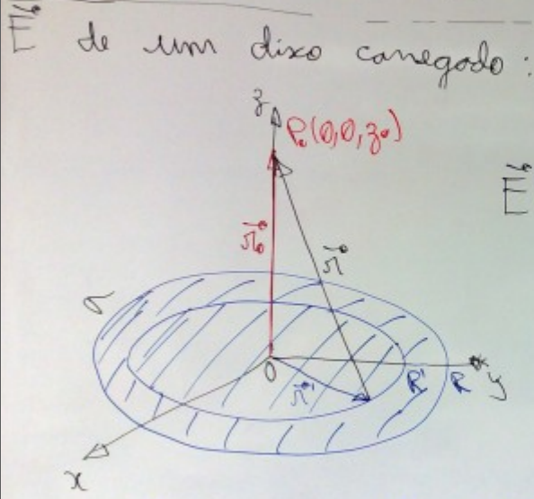

Pode-se usar o resultado anterior (1.d) para anel circular carregado eletricamente :

$$ d\vec{E} = \frac{dQ\,z_0}{4\pi\epsilon_0 (z_0^2 + \rho'^2)^{3/2}} \hat{k}$$

onde no disco $dQ = \sigma\,dA' = 2\pi \rho' \lambda_0 d\rho' $ :

$$ d\vec{E} = \frac{2\pi\,z_0\lambda_0\rho' d\rho'}{4\pi\epsilon_0 (z_0^2 + \rho'^2)^{3/2}} \hat{k} $$

tal que basta integrar em relação a $\rho'$ de $0$ m ao raio $R$ do disco :

(CONTINUA NA AULA SEGUINTE...)